# Spatial Flows & Network Transmission

- Show All Code
- Hide All Code
- View Source

Author

Eric Delmelle

Published

April 1, 2026

## Learning Objectives

1. Understand why **spatial flows** — not just locations — drive STI transmission
2. Apply the **gravity model** to predict interaction intensity between truck stops and risk environments
3. Recognize why **geographic proximity is not the dominant factor** in network-driven STI spread
4. Connect spatial interaction theory to real corridor data

## 1. Why Flows Matter

Spatial epidemiology has traditionally asked *where* disease occurs. But for sexually transmitted infections among mobile populations, the more important question is *who moves where, and how often*.

A long-haul truck driver does not acquire HIV in his home community — he acquires it along his route, at stops where he spends the night. He then carries the pathogen back home, seeding infection in a community that may be hundreds of kilometres from the original exposure site. **The geography of risk is the geography of movement.**

This has a direct implication for intervention: targeting the places where exposure happens — major overnight truck stops — is far more efficient than targeting the communities where drivers live.

### 1.1 The I-78 Corridor

We use the **I-78 corridor** as our case study — a real, familiar freight route running from Harrisburg, PA through the Lehigh Valley, across New Jersey, and into Manhattan. Extended south via I-95, it connects Philadelphia and Wilmington, DE.

I-78 carries over four million trucks annually — roughly 24% of all US truck traffic. Along this corridor, several major truck stops function as overnight rest nodes where drivers spend 10–16 hours, creating sustained exposure opportunity.

## 2. Spatial Interaction Model

### 2.1 The Gravity Model

We predict the **interaction intensity** $T_{ij}$ between a truck stop $i$ and a risk environment $j$ (here: Adult Entertainment Establishments, AEEs) using the gravity model:

$$T_{ij} = k \cdot \frac{O_i^{\,\alpha} \cdot D_j^{\,\beta}}{d_{ij}^{\,\gamma}}$$

| Symbol | Meaning in this context |
| --- | --- |
| $T_{ij}$ | Predicted interaction intensity (proxy for exposure risk) |
| $O_i$ | Origin mass — parking capacity of truck stop $i$ |
| $D_j$ | Destination mass — size / activity level of AEE $j$ |
| $d_{ij}$ | Distance between truck stop and AEE (km) |
| $k$ | Scaling constant |
| $\alpha,\,\beta$ | Mass exponents — how strongly size drives interaction |
| $\gamma$ | **Distance decay** — how sharply interaction falls with distance |

### 2.2 Why $\gamma$ Is Small for Truck Drivers

This is the critical insight. For **commuters**, $\gamma$ is large (2–3): people strongly prefer nearby destinations. For **truck drivers on overnight rest**, $\gamma$ is much smaller (0.5–1.2): drivers will travel 15–20 km from a stop if the destination is sufficiently attractive, because they have time and a vehicle.

A small $\gamma$ has two epidemiological consequences:

- Exposure is **not confined to the immediate vicinity** of the truck stop — it spreads over a wider spatial area
- The closest AEE is **not necessarily the most visited** — a larger or more well-known establishment 10 km away may attract more visits than a small one 2 km away

This is why classical nearest-neighbour assumptions break down in this context, and why a spatial interaction model is more appropriate than simple proximity analysis.

## 3. Data: Truck Stops and AEEs

```r
# ── Truck stops (origins) ─────────────────────────────────────────────────────
origins <- data.frame(
  id       = 1:5,
  name     = c("Lebanon\n(Flying J)",
               "Easton /\nPhillipsburg",
               "Bloomsbury\n(TA Center)",
               "Clinton\n(Pilot)",
               "Petro Center\n(I-295 Ex 7)"),
  lon      = c(-76.40, -75.04, -74.99, -74.90, -74.87),
  lat      = c( 40.34,  40.69,  40.67,  40.64,  39.86),
  capacity = c(200, 80, 122, 60, 490),
  stringsAsFactors = FALSE
)
origins$name_clean <- gsub("\n", " ", origins$name)
origins_sf <- st_as_sf(origins, coords = c("lon", "lat"), crs = 4326, remove = FALSE)

# ── AEEs (destinations) — simulated near highway exits ───────────────────────
set.seed(7)
aee_anchors <- data.frame(
  lon_base = c(-76.35, -76.42, -76.28,
               -75.50, -75.43,
               -75.08, -75.01,
               -74.96, -74.92, -74.88,
               -74.62, -74.55,
               -74.20, -74.15, -74.10,
               -74.05, -74.02,
               -75.20, -75.12,
               -74.90),
  lat_base = c( 40.32,  40.38,  40.30,
                40.58,  40.55,
                40.67,  40.71,
                40.65,  40.63,  40.62,
                40.55,  40.52,
                40.70,  40.68,  40.72,
                40.73,  40.71,
                39.93,  39.91,
                39.84)
)

aee <- aee_anchors %>%
  mutate(
    id     = row_number(),
    name   = paste0("AEE-", sprintf("%02d", id)),
    lon    = lon_base + runif(n(), -0.04, 0.04),
    lat    = lat_base + runif(n(), -0.02, 0.02),
    mass_D = round(runif(n(), 1, 10), 1)
  ) %>%
  select(id, name, lon, lat, mass_D)

aee_sf <- st_as_sf(aee, coords = c("lon", "lat"), crs = 4326, remove = FALSE)
```

## 4. Predicted Interactions

```r
# Full pairwise distance matrix (km)
dist_mat <- st_distance(origins_sf, aee_sf)
dist_km  <- matrix(as.numeric(dist_mat) / 1000,
                   nrow = nrow(origins), ncol = nrow(aee))

# Build OD table
od <- expand.grid(i = 1:nrow(origins), j = 1:nrow(aee)) %>%
  mutate(
    origin_name = origins$name_clean[i],
    Oi  = origins$capacity[i],
    Dj  = aee$mass_D[j],
    dij = dist_km[cbind(i, j)],
    lon_o = origins$lon[i], lat_o = origins$lat[i],
    lon_d = aee$lon[j],     lat_d = aee$lat[j]
  ) %>%
  filter(dij > 0) %>%
  mutate(
    # Gravity model: alpha = beta = 1, gamma = 0.8 (moderate decay)
    T_ij  = 1.0 * Oi * Dj / (dij^0.8),
    T_norm = T_ij / max(T_ij)
  )
```

### 4.1 Flow Map — Top Interactions

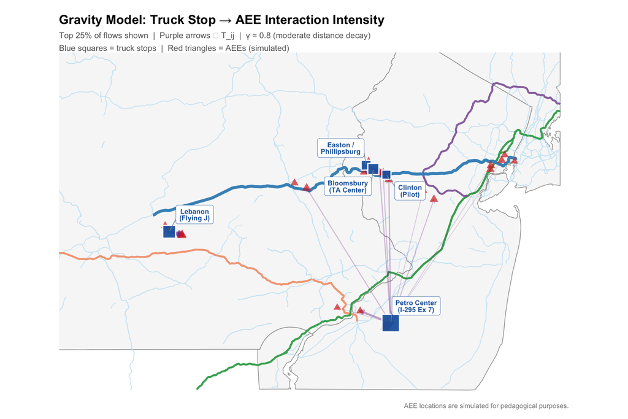

Top 25% of predicted truck stop → AEE interactions along the I-78 / I-95 corridor. Arrow width and opacity proportional to gravity-predicted interaction intensity T_ij. Blue squares = truck stops (size ∝ parking capacity); red triangles = AEEs (size ∝ activity mass). Note that the highest-intensity flows do not always connect the nearest origin-destination pair.

```r
threshold <- quantile(od$T_ij, 0.75)
od_top    <- od %>% filter(T_ij >= threshold)

ggplot() +
  # State outlines + road network for geographic context
  geom_sf(data = states, fill = "grey97", color = "grey65", linewidth = 0.35) +
  geom_sf(data = roads_primary, color = "#d0e8f5", linewidth = 0.4, alpha = 0.7) +
  geom_sf(data = hwy_i76,  color = "#f4a582", linewidth = 0.9, alpha = 0.85) +
  geom_sf(data = hwy_i95,  color = "#41ab5d", linewidth = 0.9, alpha = 0.85) +
  geom_sf(data = hwy_i287, color = "#9970ab", linewidth = 0.9, alpha = 0.85) +
  geom_sf(data = hwy_i78,  color = "#4393c3", linewidth = 1.4, alpha = 0.9) +
  # Flow arrows
  geom_segment(
    data = od_top,
    aes(x = lon_o, y = lat_o, xend = lon_d, yend = lat_d,
        linewidth = T_norm, alpha = T_norm),
    color = "#7b2d8b",
    arrow = arrow(length = unit(0.14, "cm"), type = "open"),
    lineend = "round"
  ) +
  # AEEs
  geom_point(data = aee,
             aes(x = lon, y = lat, size = mass_D),
             shape = 17, color = "#d73027", alpha = 0.7) +
  # Truck stops
  geom_point(data = origins,
             aes(x = lon, y = lat, size = capacity),
             shape = 22, fill = "#2166ac", color = "white",
             stroke = 0.9, alpha = 0.95) +
  geom_label_repel(
    data = origins,
    aes(x = lon, y = lat, label = name),
    size = 2.5, lineheight = 0.82,
    box.padding = 0.5, fill = "white",
    color = "#2166ac", fontface = "bold",
    label.size = 0.15, max.overlaps = 20,
    segment.color = "grey60", segment.size = 0.3
  ) +
  scale_linewidth_continuous(range = c(0.3, 2.8), guide = "none") +
  scale_alpha_continuous(range = c(0.2, 0.85), guide = "none") +
  scale_size_continuous(range = c(2, 9), guide = "none") +
  coord_sf(xlim = c(-77.0, -73.8), ylim = c(39.55, 41.2)) +
  labs(
    title    = "Gravity Model: Truck Stop → AEE Interaction Intensity",
    subtitle = paste0(
      "Top 25% of flows shown  |  Purple arrows ∝ T_ij  |  ",
      "γ = 0.8 (moderate distance decay)\n",
      "Blue squares = truck stops  |  Red triangles = AEEs (simulated)"
    ),
    caption  = "AEE locations are simulated for pedagogical purposes.",
    x = NULL, y = NULL
  ) +
  theme_void(base_size = 11) +
  theme(
    plot.title    = element_text(face = "bold", size = 13),
    plot.subtitle = element_text(color = "grey40", size = 8.5, lineheight = 1.3),
    plot.caption  = element_text(color = "grey55", size = 7),
    plot.margin   = margin(10, 10, 10, 10)
  )
```

### 4.2 Which Truck Stop Generates the Most Exposure?

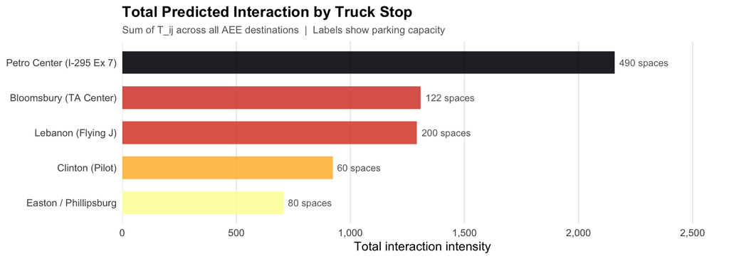

Total predicted interaction intensity by truck stop. The Petro Center dominates because of its large parking capacity (490 spaces), even though it is geographically more isolated in southern NJ.

```r
od %>%
  group_by(origin_name, Oi) %>%
  summarise(T_total = sum(T_ij), .groups = "drop") %>%
  arrange(desc(T_total)) %>%
  mutate(origin_name = factor(origin_name, levels = rev(origin_name))) %>%
  ggplot(aes(x = T_total, y = origin_name, fill = T_total)) +
  geom_col(alpha = 0.88, width = 0.65) +
  geom_text(aes(label = paste0(Oi, " spaces")),
            hjust = -0.1, size = 3, color = "grey40") +
  scale_fill_viridis_c(option = "inferno", direction = -1, guide = "none") +
  scale_x_continuous(expand = expansion(mult = c(0, 0.22)), labels = comma) +
  labs(
    title    = "Total Predicted Interaction by Truck Stop",
    subtitle = "Sum of T_ij across all AEE destinations  |  Labels show parking capacity",
    x = "Total interaction intensity", y = NULL
  ) +
  theme_minimal(base_size = 11) +
  theme(
    plot.title         = element_text(face = "bold"),
    plot.subtitle      = element_text(color = "grey40", size = 9),
    panel.grid.major.y = element_blank(),
    panel.grid.minor   = element_blank()
  )
```

## 5. The Non-Nearest-Neighbour Problem

The map above makes a key point visible: **the strongest flows do not always connect the nearest origin-destination pair**. The Petro Center (I-295, southern NJ) attracts high-intensity flows to AEEs that are geographically distant, simply because its parking capacity is so large.

This matters for two reasons:

**Methodologically**: a simple kernel density or nearest-neighbour analysis of AEE proximity to truck stops would miss this entirely. It would flag the closest AEE to each truck stop as the highest-risk destination — but the gravity model shows that a large, well-known establishment 15 km away can easily generate more visits than a small one 3 km away.

**For intervention**: if you only target the AEEs closest to truck stops, you may be missing the high-volume destinations that actually drive most of the transmission. The gravity model helps prioritize by predicted volume, not just proximity.

This is consistent with the broader network epidemiology literature — Brockmann & Helbing (2013) showed that “effective distance” in a flow network predicts epidemic spread far better than geographic distance. The same principle applies here at the corridor scale.

### 5.1 Sensitivity to $\gamma$

How much does the choice of $\gamma$ affect the results?

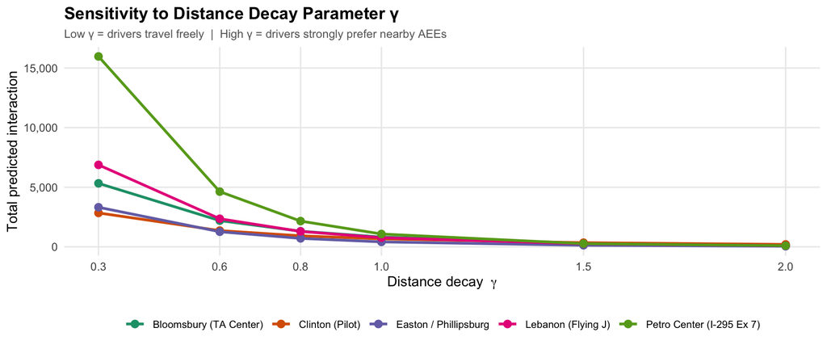

Sensitivity of total predicted interaction to distance decay γ. At low γ (weak decay), the Petro Center dominates overwhelmingly due to its size. At high γ (strong decay), smaller stops closer to dense AEE clusters become relatively more important.

```r
gammas <- c(0.3, 0.6, 0.8, 1.0, 1.5, 2.0)

lapply(gammas, function(g) {
  od %>%
    mutate(T_g = Oi * Dj / (dij^g)) %>%
    group_by(origin_name) %>%
    summarise(T_total = sum(T_g), .groups = "drop") %>%
    mutate(gamma = g)
}) %>%
  bind_rows() %>%
  ggplot(aes(x = gamma, y = T_total,
             color = origin_name, group = origin_name)) +
  geom_line(linewidth = 1.0) +
  geom_point(size = 2.5) +
  scale_color_brewer(palette = "Dark2", name = NULL) +
  scale_y_continuous(labels = comma) +
  scale_x_continuous(breaks = gammas) +
  labs(
    title    = "Sensitivity to Distance Decay Parameter γ",
    subtitle = "Low γ = drivers travel freely  |  High γ = drivers strongly prefer nearby AEEs",
    x = expression(paste("Distance decay  ", gamma)),
    y = "Total predicted interaction"
  ) +
  theme_minimal(base_size = 11) +
  theme(
    plot.title       = element_text(face = "bold"),
    plot.subtitle    = element_text(color = "grey40", size = 9),
    panel.grid.minor = element_blank(),
    legend.position  = "bottom",
    legend.text      = element_text(size = 8)
  )
```

## 6. A Single Epidemic Snapshot

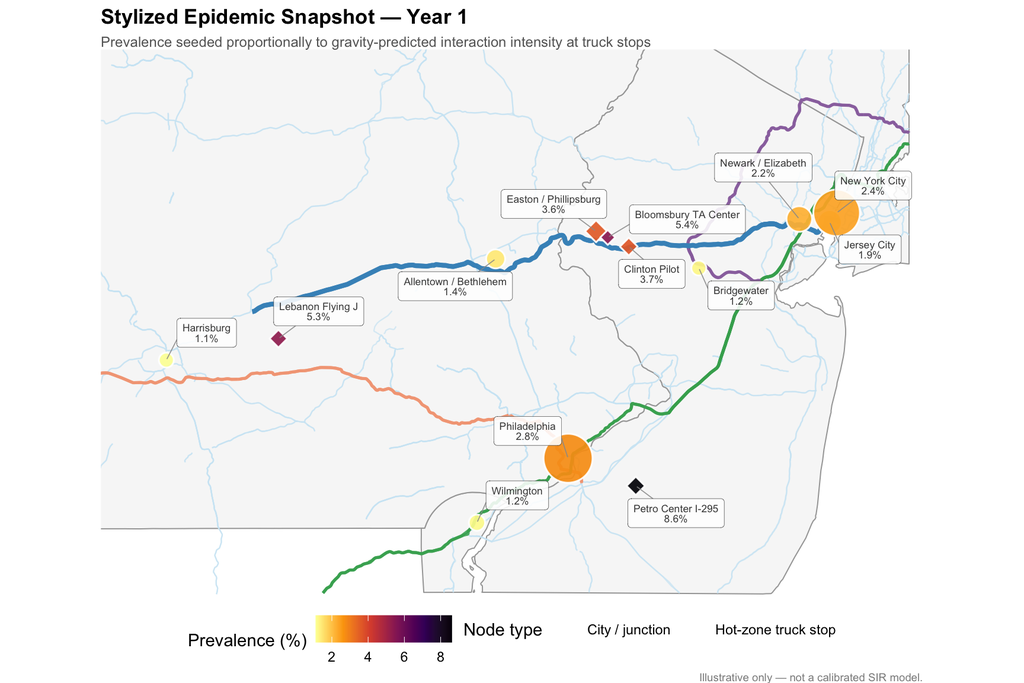

Simulated prevalence at corridor nodes after 1 year, seeded proportionally to total predicted interaction intensity at each truck stop. Node size = infected population; color = prevalence. This is a stylized illustration — not a calibrated epidemic model.

```r
set.seed(42)

# Simple nodes for illustration
corridor_nodes <- data.frame(
  name  = c("Harrisburg", "Lebanon\nFlying J", "Allentown /\nBethlehem",
            "Easton /\nPhillipsburg", "Bloomsbury\nTA Center",
            "Clinton\nPilot", "Bridgewater", "Newark /\nElizabeth",
            "Jersey City", "New York City",
            "Philadelphia", "Petro Center\nI-295", "Wilmington"),
  lon   = c(-76.88, -76.40, -75.47, -75.04, -74.99,
            -74.90, -74.60, -74.17, -74.04, -74.01,
            -75.16, -74.87, -75.55),
  lat   = c( 40.27,  40.34,  40.60,  40.69,  40.67,
             40.64,  40.57,  40.73,  40.72,  40.75,
             39.95,  39.86,  39.74),
  pop   = c(50000, 8000, 130000, 35000, 5000,
            12000, 45000, 280000, 260000, 1600000,
            1600000, 6000, 70000),
  hot_zone = c(FALSE, TRUE, FALSE, TRUE, TRUE,
               TRUE, FALSE, FALSE, FALSE, FALSE,
               FALSE, TRUE, FALSE),
  stringsAsFactors = FALSE
)

# Seed proportionally to total gravity interaction at hot zones,
# then diffuse modestly to neighbours — purely illustrative
interaction_totals <- od %>%
  group_by(i) %>%
  summarise(T_total = sum(T_ij), .groups = "drop")

# Map truck stop ids to corridor node ids
stop_node_map <- c(2, 4, 5, 6, 12)  # Lebanon, Easton, Bloomsbury, Clinton, Petro

seed_prev <- rep(0.5, nrow(corridor_nodes))  # baseline
for (k in seq_along(stop_node_map)) {
  node_id <- stop_node_map[k]
  seed_prev[node_id] <- seed_prev[node_id] +
    interaction_totals$T_total[k] / max(interaction_totals$T_total) * 8
}

# Simple diffusion: each node gets 15% of average neighbours' seed
set.seed(1)
final_prev <- seed_prev + rnorm(nrow(corridor_nodes), 0, 0.3) +
  c(0.8, 0, 1.2, 0, 0, 0, 0.6, 1.5, 1.2, 2.0, 1.8, 0, 0.9)
final_prev <- pmax(final_prev, 0.3)

corridor_nodes$prevalence <- final_prev
corridor_nodes$I          <- round(corridor_nodes$pop * final_prev / 100)
corridor_nodes$name_clean <- gsub("\n", " ", corridor_nodes$name)

ggplot() +
  geom_sf(data = states, fill = "grey97", color = "grey65", linewidth = 0.35) +
  geom_sf(data = roads_primary, color = "#d0e8f5", linewidth = 0.4, alpha = 0.7) +
  geom_sf(data = hwy_i76,  color = "#f4a582", linewidth = 0.9, alpha = 0.85) +
  geom_sf(data = hwy_i95,  color = "#41ab5d", linewidth = 0.9, alpha = 0.85) +
  geom_sf(data = hwy_i287, color = "#9970ab", linewidth = 0.9, alpha = 0.85) +
  geom_sf(data = hwy_i78,  color = "#4393c3", linewidth = 1.4, alpha = 0.9) +
  geom_point(data = corridor_nodes,
    aes(x = lon, y = lat, size = I, fill = prevalence, shape = hot_zone),
    color = "white", stroke = 0.8, alpha = 0.92
  ) +
  geom_label_repel(
    data = corridor_nodes,
    aes(x = lon, y = lat,
        label = paste0(name_clean, "\n", round(prevalence, 1), "%")),
    size = 2.3, lineheight = 0.82,
    box.padding = 0.5, fill = "white",
    color = "grey15", alpha = 0.88,
    label.size = 0.12, max.overlaps = 20,
    segment.color = "grey60", segment.size = 0.3
  ) +
  scale_fill_viridis_c(
    option = "inferno", direction = -1,
    name = "Prevalence (%)"
  ) +
  scale_shape_manual(
    values = c("FALSE" = 21, "TRUE" = 23),
    labels = c("City / junction", "Hot-zone truck stop"),
    name   = "Node type"
  ) +
  scale_size_continuous(range = c(3, 14), guide = "none") +
  coord_sf(xlim = c(-77.0, -73.8), ylim = c(39.55, 41.2)) +
  labs(
    title    = "Stylized Epidemic Snapshot — Year 1",
    subtitle = "Prevalence seeded proportionally to gravity-predicted interaction intensity at truck stops",
    caption  = "Illustrative only — not a calibrated SIR model.",
    x = NULL, y = NULL
  ) +
  theme_void(base_size = 11) +
  theme(
    plot.title    = element_text(face = "bold", size = 13),
    plot.subtitle = element_text(color = "grey40", size = 9),
    plot.caption  = element_text(color = "grey55", size = 7),
    legend.position = "bottom"
  )
```

## 7. Discussion Questions

1. The Petro Center has 490 parking spaces but is geographically more isolated than other stops. Does the gravity model make it a high-priority intervention site? What real-world factors might reduce or amplify its predicted importance?
2. We used $\gamma = 0.8$ for truck drivers. How would you empirically estimate $\gamma$ for this population? What data would you need?
3. The gravity model assumes AEE **mass** ($D_j$) drives attractiveness. What other variables — not captured by size alone — might predict how many drivers visit a given establishment?
4. **Graduate extension**: How does this single-corridor model connect to Laura’s analysis of AEE density at the census-tract level in Pennsylvania? What additional spatial layer would you need to link the two analyses?

## References

- Brockmann, D. & Helbing, D. (2013). The hidden geometry of complex, network-driven contagion phenomena. *Science*, 342(6164), 1337–1342.
- Decker, M.R., et al. (2012). Gender-based violence, STIs, and HIV among female sex workers. *Sexually Transmitted Infections*, 88(3), 173–176.
- Howe, L.D., et al. (2008). HIV among truck drivers in sub-Saharan Africa. *AIDS Care*, 20(10), 1175–1183.
- Sen, A. & Smith, T. (1995). *Gravity Models of Spatial Interaction Behavior*. Springer.